# Beads community trait data

Author

Masatoshi Katabuchi

Published

November 2, 2026

# 1 Phylo

The bundled reference tree is a snapshot of the previously distributed dummy tree. The original `qjzad.tre` is unavailable; this snapshot fixes the topology and branch lengths used for regeneration. Branch lengths are in arbitrary units.

```r
set.seed(123)
tr <- read.tree("data-raw/dummy_reference.newick")
sp <- tr$tip.label
tr_dist <- vcv(tr) |> cov2cor()

phy_tr <- MASS::mvrnorm(2, rep(0, ncol(tr_dist)), tr_dist)

tmp <- tibble(tmp = phy_tr[1, ], sp = colnames(tr_dist)) |>
  arrange(tmp)
```

## 1.1 Mass artifact and phylogenetic signal

```r
d <- read_csv("data/nature02403-s2.csv", skip = 10) |>
  janitor::clean_names()
```

[output not shown]

```r
data <- d |>
  dplyr::select(sp = species, log_ll, log_lma, log_amass, log_nmass, log_pmass, log_rdmass) |>
  filter(!is.na(log_lma)) |>
  mutate(across(starts_with("log_"), ~ . * log(10)))

log_lma <- data |>
  pull(log_lma)

lma <- exp(log_lma)

data |>
  pull(log_amass) |>
  exp() |>
  summary()
```

```
   Min. 1st Qu.  Median    Mean 3rd Qu.    Max.     NAs
  4.786  57.544 101.165 128.730 162.181 660.693    1606
```

Dummy LL follows the fitted log-scale regression of LL on LMA, with residual SD from that regression. This preserves the fitted conditional mean of log LL.

```r
fit <- lm(log_ll ~ log_lma, data = data)
ll <- rlnorm(length(lma),
             meanlog = predict(fit, newdata = data),
             sdlog = sigma(fit))
```

Dummy A_mass is based on Model-A in Osnas et al. 2013.

$$X_{MiK} = \bar{X_{Ai}} LMA_k^{-1} \epsilon_{Aik}$$

For Amass, $\bar{X_{Ai}}$ = 11642. The multiplicative error has mean 1, with $\log \epsilon_{Aik} \sim N(-0.55^2/2, 0.55^2)$.

```r
a_mass <- rlnorm(length(lma),
               log(11642  / lma) - 0.55^2 /2,
               0.55)
```

I don’t add area-based traits in the data, but they can be calculated as follows:

$$X_{AiK} = X_{Mik} LMA_k.$$

Other LES traits are also based on Model-A.

```r
r_mass <- rlnorm(length(lma),
               log(1402  / lma) - 0.5^2 /2,
               0.5)

n_mass <- rlnorm(length(lma),
               log(1.94  / lma) - 0.46^2 /2,
               0.46)

p_mass <- rlnorm(length(lma),
               log(0.1305  / lma) - 0.6^2 /2,
               0.6)
```

Wood density and the initial seed-size score are generated independently of LES. The score is converted to genus-specific seed masses after species assignment.

```r
wd <- rlnorm(length(lma),
             log(0.6) - 0.2^2 / 2., 0.2)

sm <- rlnorm(length(lma),
             log(2.3) - 1^2 / 2., 1)
```

Add the phylogenetic signal to the above data.

```r
data2 <- tibble(
  lma,
  ll,
  a_mass,
  r_mass,
  n_mass = n_mass * 100,
  p_mass = p_mass * 100,
  wd,
  sm) |>
  round(2) |>
  sample_n(length(sp)) |>
  arrange(lma)

dummy_trait <- bind_cols(tmp, data2) |>
  arrange(-sm)

# Assign the three largest seed masses to the focal Fagaceae species.
# Recompute each position after swapping, since earlier swaps move labels.
seed_species <- c("Lithocarpus_henryi", "Lithocarpus_xylocarpus",
                  "Castanopsis_wattii")
for (i in seq_along(seed_species)) {
  target <- match(seed_species[i], dummy_trait$sp)
  stopifnot(!is.na(target))
  dummy_trait$sp[c(i, target)] <- dummy_trait$sp[c(target, i)]
}

# Keep species assignments and other traits fixed, then replace the seed-size
# score with a mass in mg. No additional random draws are needed.
seed_ranges <- read_csv("data-raw/seed_mass_ranges.csv", show_col_types = FALSE)
genus <- sub("_.*", "", dummy_trait$sp)
bounds <- seed_ranges[match(genus, seed_ranges$genus), ]
stopifnot(!anyNA(bounds), !anyDuplicated(seed_ranges$genus))
u <- pnorm(as.numeric(scale(log(dummy_trait$sm))))
dummy_trait$sm <- signif(exp(log(bounds$min_mg) +
  u * (log(bounds$max_mg) - log(bounds$min_mg))), 5)

# Rounded teaching anchors, informed by seed-size reports; these are simulated
# values, not measured dry masses or copied species means.
anchors <- c(Lithocarpus_xylocarpus = 6000, Lithocarpus_hancei = 2200,
             Castanopsis_wattii = 1500, Machilus_yunnanensis = 1200)
idx <- match(names(anchors), dummy_trait$sp)
stopifnot(!anyNA(idx))
dummy_trait$sm[idx] <- unname(anchors)

dummy_trait <- dummy_trait |>
  arrange(sp)

summary(dummy_trait)
```

```
      tmp                  sp          lma               ll
 Min.   :-1.2690   Length   :77   Min.   : 23.99   Min.   :  0.63
 1st Qu.:-0.2534   N.unique :77   1st Qu.: 56.23   1st Qu.:  3.30
 Median : 0.2763   N.blank  : 0   Median : 87.10   Median :  7.96
 Mean   : 0.3273   Min.nchar: 8   Mean   :107.57   Mean   : 12.23
 3rd Qu.: 0.9227   Max.nchar:27   3rd Qu.:131.83   3rd Qu.: 12.81
 Max.   : 2.0552                  Max.   :457.09   Max.   :106.75
     a_mass            r_mass          n_mass           p_mass
 Min.   :  14.74   Min.   : 2.69   Min.   : 0.390   Min.   :0.0100
 1st Qu.:  79.28   1st Qu.: 7.78   1st Qu.: 1.120   1st Qu.:0.0600
 Median : 126.01   Median :15.62   Median : 2.280   Median :0.1200
 Mean   : 155.45   Mean   :19.49   Mean   : 2.722   Mean   :0.2048
 3rd Qu.: 193.01   3rd Qu.:26.46   3rd Qu.: 3.500   3rd Qu.:0.3000
 Max.   :1016.57   Max.   :86.56   Max.   :10.490   Max.   :1.0300
       wd               sm
 Min.   :0.3500   Min.   :   0.0124
 1st Qu.:0.5100   1st Qu.:   2.5731
 Median :0.5900   Median :  54.9310
 Mean   :0.5984   Mean   : 609.0950
 3rd Qu.:0.6800   3rd Qu.: 645.7900
 Max.   :0.8900   Max.   :7641.8000
```

Units are:

- LMA (g m<sup>-2</sup>)
- LL (months)
- *A*<sub>mass</sub> (nmol g<sup>-1</sup> s<sup>-1</sup>)
- *R*<sub>mass</sub> (nmol g<sup>-1</sup> s<sup>-1</sup>)
- *N*<sub>mass</sub> (%)
- *P*<sub>mass</sub> (%)
- Wood density (g cm<sup>-3</sup>)
- Seed mass (mg per seed; simulated size scale, not a measured dry-mass dataset)

Seed mass uses the explicit genus-specific simulation bounds in `data-raw/seed_mass_ranges.csv`. Values are interpolated on the log scale using normal quantiles of the initial seed-size score. The bounds are broad teaching assumptions, not empirical species confidence intervals. Genus membership now contributes to seed-size structure; independence from LES is not imposed on the final values. The earlier label swaps retain the existing species assignments and other traits; they no longer guarantee the three largest seed masses.

Rounded anchors for *L. xylocarpus*, *L. hancei*, *C. wattii* and *M. yunnanensis* follow the order of magnitude reported by [Lang & Wang (2016)](https://iforest.sisef.org/contents/?id=ifor1852-008). That study weighed intact refrigerated seeds after removing woody receptacles where applicable; it does not establish oven-dry seed mass. We therefore use these reports only as size guides. Small-seeded *Rhododendron* bounds are guided by the thousand-seed weights in [Wang et al. (2014)](https://pmc.ncbi.nlm.nih.gov/articles/PMC4063484/). All values remain fictional exercise traits, including the rounded anchors.

```r
dummy_trait |>
  DT::datatable()
```

|  | tmp | sp | lma | ll | a_mass | r_mass | n_mass | p_mass | wd | sm |
| --- | --- | --- | --- | --- | --- | --- | --- | --- | --- | --- |
| 1 | 0.4214140448662724 | Acer_campbellii | 95.5 | 7.96 | 169.07 | 41.16 | 1.27 | 0.1 | 0.62 | 13.598 |
| 2 | -0.600954065789179 | Actinodaphne_forrestii | 46.77 | 2.41 | 219.39 | 26.46 | 3.5 | 0.29 | 0.58 | 1129.5 |
| 3 | 1.462336176100227 | Alnus_nepalensis | 234.42 | 51.28 | 40.82 | 7.35 | 0.8 | 0.09 | 0.51 | 0.33337 |
| 4 | 0.2503901380688483 | Anneslea_fragrans | 85.11 | 4.06 | 117.89 | 28.06 | 2.64 | 0.09 | 0.5 | 54.931 |
| 5 | 0.6055540159326792 | Beilschmiedia_robusta | 107.15 | 8.13 | 155.62 | 11.2 | 2.4 | 0.04 | 0.6 | 2151.3 |
| 6 | 1.240860200178177 | Betula_alnoides | 181.97 | 29.44 | 98.96 | 4.65 | 2.37 | 0.04 | 0.62 | 0.96538 |
| 7 | -0.1433730739620381 | Camellia_Pitardii | 61.66 | 8.09 | 223.48 | 21.2 | 2.15 | 0.3 | 0.63 | 750.01 |
| 8 | -0.4974944800602872 | Camellia_assamica | 47.86 | 2.06 | 159.87 | 11.92 | 6.73 | 0.41 | 0.55 | 1029.2 |
| 9 | -0.811291265945171 | Camellia_forrestii | 39.81 | 4.84 | 1016.57 | 48.83 | 6.23 | 0.29 | 0.72 | 341.88 |
| 10 | -0.7583251617829809 | Camellia_yunnanensis | 40.74 | 1.35 | 206.4 | 16.1 | 3.56 | 0.45 | 0.42 | 318.08 |

[output cut: 67 more lines]

```r
# Select the top and bottom species for 'sm' and 'lma' simultaneously
lma_sp <- dummy_trait %>%
  arrange(lma) %>%
  slice(c(1:5, (n()-4):n())) %>%
  pull(sp)
sm_sp <- dummy_trait %>%
  arrange(sm) %>%
  slice(c(1:5, (n()-4):n())) %>%
  pull(sp)

# Extract unique and sorted species names in one step
focal_sp <- unique(c(lma_sp, sm_sp)) %>%
  sort()

focal_sp
```

```
 [1] "Alnus_nepalensis"            "Camellia_forrestii"
 [3] "Castanopsis_echidnocarpa"    "Cyclobalanopsis_stewardiana"
 [5] "Lithocarpus_confinis"        "Lithocarpus_crassifolius"
 [7] "Lithocarpus_henryi"          "Lithocarpus_truncatus"
 [9] "Lithocarpus_xylocarpus"      "Machilus_yunnanensis"
[11] "Meliosma_arnottiana"         "Meliosma_kirkii"
[13] "Osbeckia_mepalensis"         "Padus_napaulensis"
[15] "Rhododendron_decorum"        "Rhododendron_irroratum"
[17] "Rhododendron_leptothrium"    "Skimmia_arborescens"
[19] "Symplocos_ramosissima"       "Vaccinium_duclouxii"
```

# 2 Check PCA

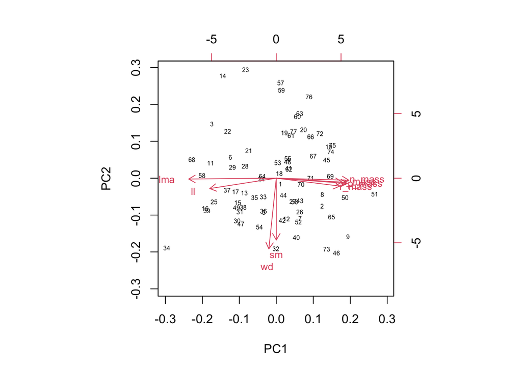

```r
pca_res <- prcomp(log(as.data.frame(dummy_trait[, 3:10])), scale = TRUE)

biplot(pca_res, choices = c(1, 2), cex = c(0.5, 0.8))
```

# 3 Check k signal

```r
tr3 <- tr # Keep the bundled topology and branch lengths fixed.

physig_tb <- tibble()
for (i in 3:10) {
  x <- dummy_trait[,i] %>% unlist
  names(x) <- dummy_trait$sp
  physig_tb  <- bind_rows(physig_tb, phylosignal(x[tr3$tip.label], tr3))
}

physig_tb2 <- physig_tb %>%
  mutate(trait = names(dummy_trait)[3:10])

physig_tb2
```

```
# A tibble: 8 × 6
      K PIC.variance.obs PIC.variance.rnd.mean PIC.variance.P PIC.variance.Z
  <dbl>            <dbl>                 <dbl>          <dbl>          <dbl>
1 0.210        32659.                37055.             0.337         -0.522
2 0.138         2486.                 1923.             0.835          0.999
3 0.131       202215.               150591.             0.838          1.05
4 0.236         1316.                 1765.             0.087         -1.23
5 0.359           17.0                  34.2            0.001         -2.93
6 0.298            0.170                 0.283          0.005         -2.04
7 0.194            0.105                 0.111          0.345         -0.423
8 0.233      9975477.             12215332.             0.293         -0.634
# ℹ 1 more variable: trait <chr>
```

# 4 Save

```r
dummy_trait %>%
  dplyr::select(-tmp) |>
  arrange(sp) |>
  write_csv("data/dummy_trait.csv")

tr3 |>
  write.tree("data/dummy_tree.newick")
```